# Project STA 141 by Robert Zhu

2025-03-13

Background

In this project, we analyze a subset of data collected by Steinmetz et al. (2019). In the study conducted by Steinmetz et al. (2019), experiments were performed on a total of 10 mice over 39 sessions. Each session comprised several hundred trials, during which visual stimuli were randomly presented to the mouse on two screens positioned on both sides of it. The stimuli varied in terms of contrast levels, which took values in {0, 0.25, 0.5, 1}, with 0 indicating the absence of a stimulus. The mice were required to make decisions based on the visual stimuli, using a wheel controlled by their forepaws. A reward or penalty (i.e., feedback) was subsequently administered based on the outcome of their decisions. In particular,

When left contrast > right contrast, success (1) if turning the wheel to the right and failure (-1) otherwise. When right contrast > left contrast, success (1) if turning the wheel to the left and failure (-1) otherwise. When both left and right contrasts are zero, success (1) if holding the wheel still and failure (-1) otherwise. When left and right contrasts are equal but non-zero, left or right will be randomly chosen (50%) as the correct choice. The activity of the neurons in the mice’s visual cortex was recorded during the trials and made available in the form of spike trains, which are collections of timestamps corresponding to neuron firing. In this project, we focus specifically on the spike trains of neurons from the onset of the stimuli to 0.4 seconds post-onset.

```
## Session 1 - Mouse: Cori , Date: 2016-12-14
## Session 2 - Mouse: Cori , Date: 2016-12-17
## Session 3 - Mouse: Cori , Date: 2016-12-18
## Session 4 - Mouse: Forssmann , Date: 2017-11-01
## Session 5 - Mouse: Forssmann , Date: 2017-11-02
## Session 6 - Mouse: Forssmann , Date: 2017-11-04
## Session 7 - Mouse: Forssmann , Date: 2017-11-05
## Session 8 - Mouse: Hench , Date: 2017-06-15
## Session 9 - Mouse: Hench , Date: 2017-06-16
## Session 10 - Mouse: Hench , Date: 2017-06-17
## Session 11 - Mouse: Hench , Date: 2017-06-18
## Session 12 - Mouse: Lederberg , Date: 2017-12-05
## Session 13 - Mouse: Lederberg , Date: 2017-12-06
## Session 14 - Mouse: Lederberg , Date: 2017-12-07
## Session 15 - Mouse: Lederberg , Date: 2017-12-08
## Session 16 - Mouse: Lederberg , Date: 2017-12-09
## Session 17 - Mouse: Lederberg , Date: 2017-12-10
## Session 18 - Mouse: Lederberg , Date: 2017-12-11
```

```
## [1] "contrast_left"  "contrast_right" "feedback_type"  "mouse_name"
## [5] "brain_area"     "date_exp"       "spks"           "time"
```

contrast_left: contrast of the left stimulus contrast_right: contrast of the right stimulus feedback_type: type of the feedback, 1 for success and -1 for failure spks: numbers of spikes of neurons in the visual cortex in time bins defined in time brain_area: area of the brain where each neuron lives time: centers of the time bins for spks spks: numbers of spikes of neurons in the visual cortex in time bins defined in time mouse_name: name of the 4 mice

[output not shown]

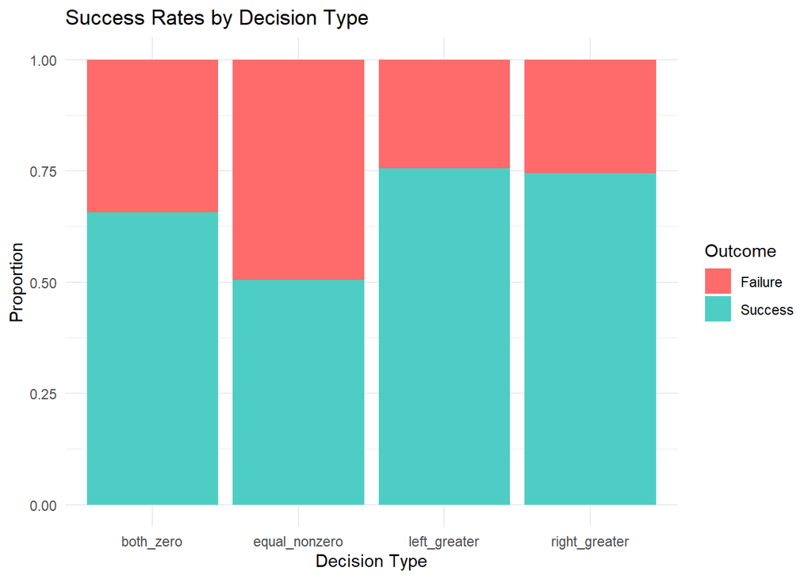

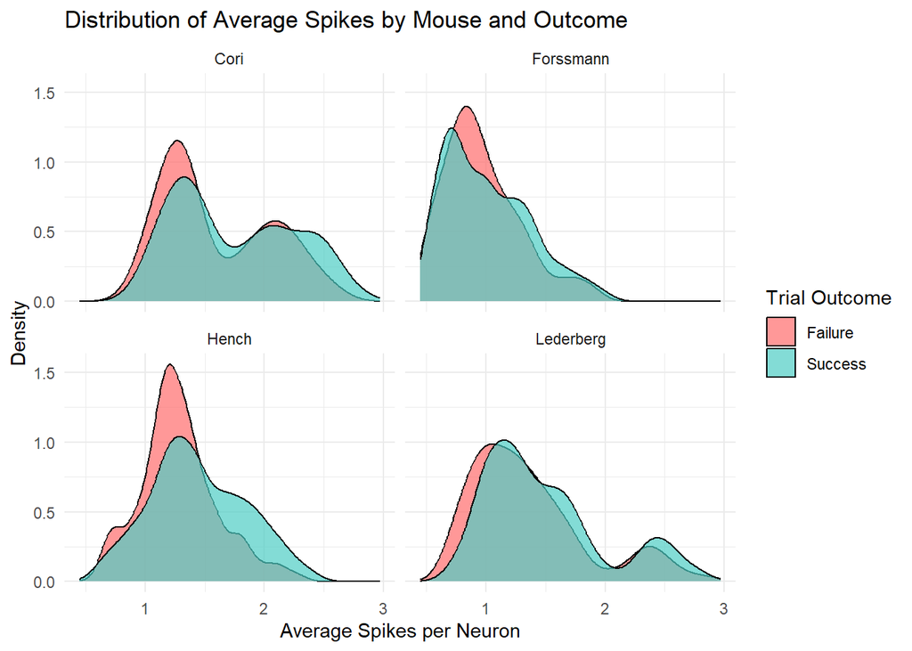

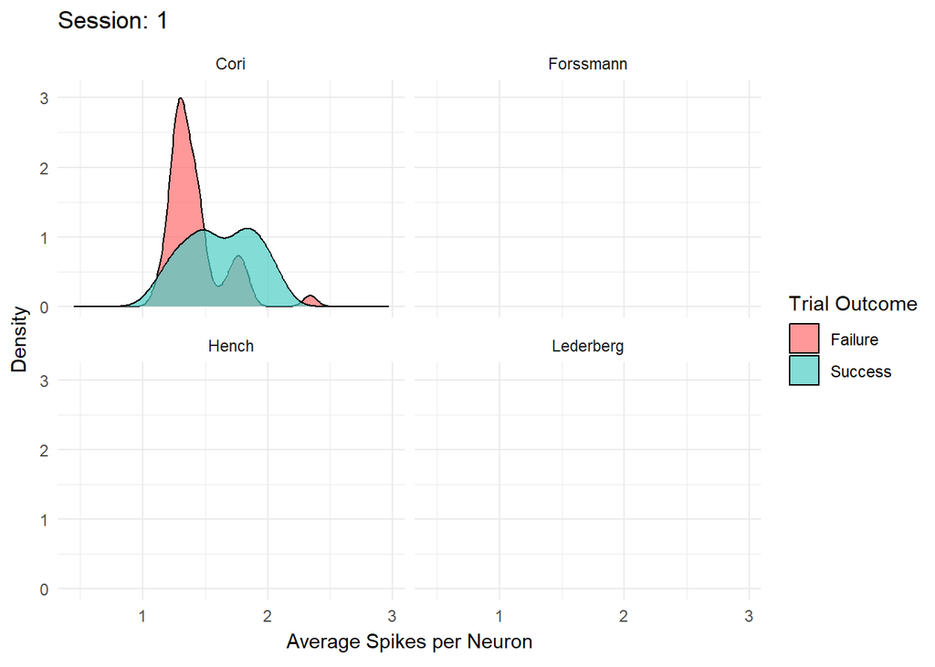

In success rate by decision type, turning left and right has the highest success rate. Equal_nonezero represents the lowest at 50%. This is because “When left and right contrasts are equal but non-zero, left or right will be randomly chosen (50%) as the correct choice.” In Distribution of Average Spikes by Mouse and Outcome, the distribution of average spikes per neuron is shown for each mouse, with the density of spikes colored by the outcome of the trial (success or failure). The plot provides insights into the neural activity patterns associated with different outcomes.

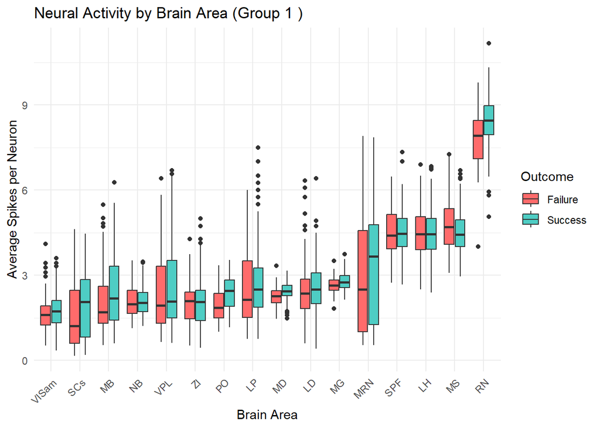

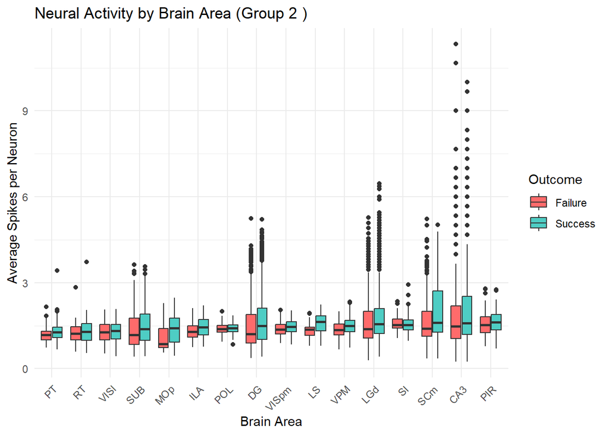

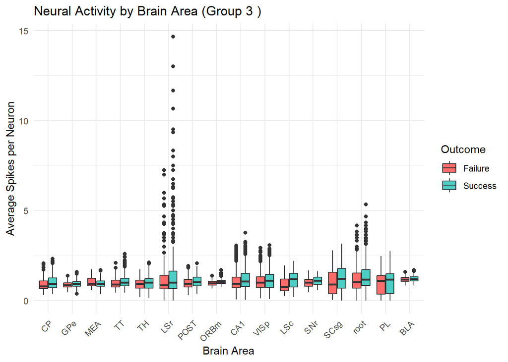

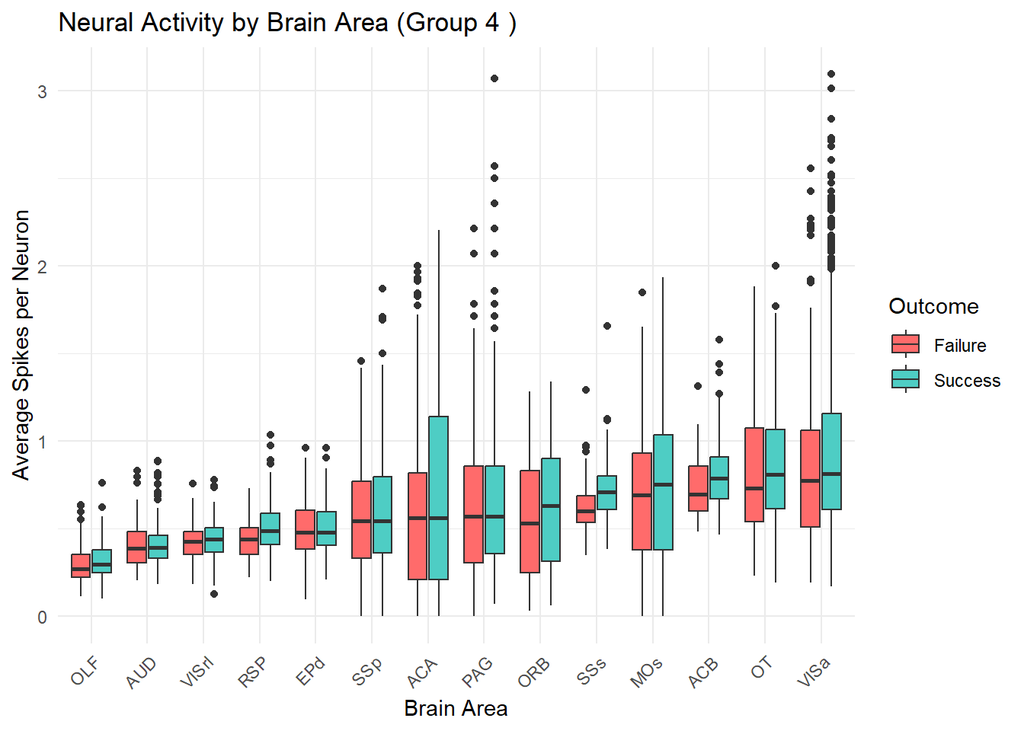

In Neural Activity by Brain Area, the box-plots show the distribution of average spikes per neuron for each brain area, grouped by the outcome of the trial (success or failure). The original plot cluster all area into one plot, and now it is divided into 4 parts so it is easier to see.

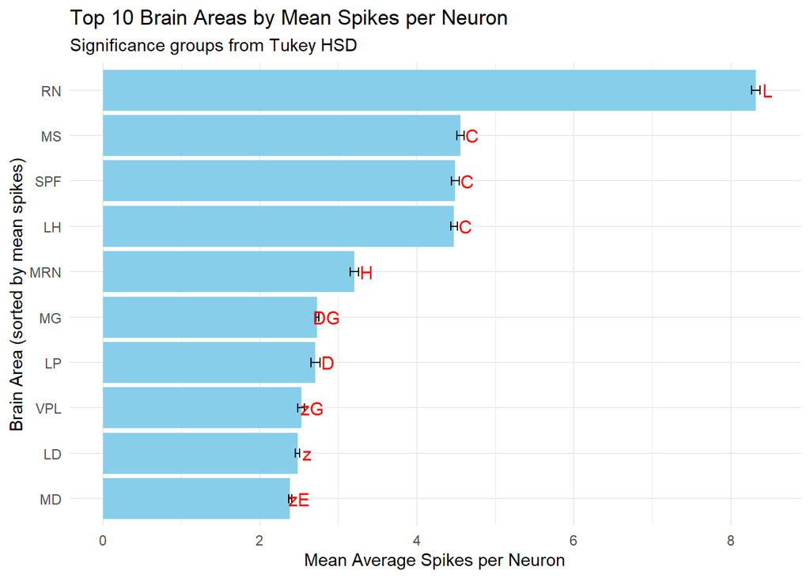

In Top 10 Brain Areas by Mean Spikes per Neuron, the top 10 brain areas with the highest mean average spikes are shown in a bar plot. The red letters indicate significant differences between groups based on Tukey’s HSD test.

```
##
## Failure Success
##       0       0
```

```
##
## Failure Success
##    1473    3608
```

```
## Rows in normalized_data: 5081
```

```
## Rows in model_data after na.omit(): 0
```

```
## Columns with less than 50% NA values:
```

```
##  [1] "session_id"          "mouse_name"          "contrast_left"
##  [4] "contrast_right"      "feedback"            "decision_type"
##  [7] "avg_spikes"          "area_root"           "area_CA1"
## [10] "contrast_left_norm"  "contrast_right_norm" "avg_spikes_norm"
## [13] "area_root_norm"      "area_CA1_norm"
```

```
## Rows in model_data after selective filtering: 5081
```

```
##
## Failure Success
##    1473    3608
```

```
## Final model_data rows: 0
```

```
##
## Failure Success
##       0       0
```

```
## named numeric(0)
```

```
## [1] "Rows before NA removal: 5081"
```

```
## [1] "Rows after NA removal: 5081"
```

```
##
## Failure Success
##    1473    3608
```

```
## Training data distribution:
```

```
##
## Failure Success
##    1179    2887
```

```
## Testing data distribution:
```

```
##
## Failure Success
##     294     721
```

```
##
## ===== Logistic Regression Model Performance =====
```

```
## Accuracy: 70.44%
```

```
## 95% CI: (67.53% - 73.24%)
```

```
## Sensitivity (True Positive Rate): 6.80%
```

```
## Specificity (True Negative Rate): 96.39%
```

```
## F1 Score: 0.12
```

```
## AUC: 0.681
```

```
##
## Logistic Regression Summary:
```

```
##
## Call:
## glm(formula = model_formula, family = "binomial", data = train_data)
##
## Coefficients: (1 not defined because of singularities)
##                              Estimate Std. Error z value Pr(>|z|)
## (Intercept)                -0.0402389  0.6402774  -0.063 0.949889
## contrast_left               0.1609058  0.1946864   0.826 0.408528
## contrast_right             -0.4370024  0.1995867  -2.190 0.028558 *
## decision_typeequal_nonzero -0.6824911  0.1915712  -3.563 0.000367 ***
## decision_typeleft_greater   0.2002629  0.1653203   1.211 0.225756
## decision_typeright_greater  0.5435712  0.1726150   3.149 0.001638 **
## avg_spikes                  3.5393802  0.9005928   3.930 8.49e-05 ***
## med_spikes                 -0.0652400  0.2092313  -0.312 0.755187
## max_spikes                  0.0001017  0.0051832   0.020 0.984350
## spike_var                   0.0130956  0.0208140   0.629 0.529238
## early_avg                  -6.4357084  1.8127588  -3.550 0.000385 ***
## late_avg                           NA         NA      NA       NA
## response_ratio              0.1261279  0.6254425   0.202 0.840181
## ---
## Signif. codes:  0 '***' 0.001 '**' 0.01 '*' 0.05 '.' 0.1 ' ' 1
##
## (Dispersion parameter for binomial family taken to be 1)
##
##     Null deviance: 4896.4  on 4065  degrees of freedom
## Residual deviance: 4649.8  on 4054  degrees of freedom
## AIC: 4673.8
##
## Number of Fisher Scoring iterations: 4
```

[output not shown]

```
##
## Training Random Forest with randomForest package...
```

```
## Training data dimensions: 4066 14
```

```
##
## RandomForest Information:
```

```
##
## Call:
##  randomForest(formula = model_formula, data = rf_train, ntree = 200,      importance = TRUE, mtry = floor(sqrt(length(predictors))))
##                Type of random forest: classification
##                      Number of trees: 200
## No. of variables tried at each split: 3
##
##         OOB estimate of  error rate: 30.32%
## Confusion matrix:
##         Failure Success class.error
## Failure     272     907    0.769296
## Success     326    2561    0.112920
```

```
##
## ===== Random Forest Model Performance =====
```

```
## Accuracy: 72.12%
```

```
## 95% CI: (69.25% - 74.86%)
```

```
## Sensitivity (True Positive Rate): 25.17%
```

```
## Specificity (True Negative Rate): 91.26%
```

```
## F1 Score: 0.34
```

```
## AUC: 0.715
```

```
##
## ==== STEP 1: Tuning Learning Rate and Tree Complexity ====
```

```
##
## Best parameters after Step 1:
```

```
## $objective
## [1] "binary:logistic"
##
## $eval_metric
## [1] "logloss"
##
## $eta
## [1] 0.05
##
## $max_depth
## [1] 4
##
## $subsample
## [1] 0.8
##
## $colsample_bytree
## [1] 0.8
##
## $min_child_weight
## [1] 1
##
## $gamma
## [1] 0
```

```
## Best number of iterations: 104
```

```
##
## ==== STEP 2: Tuning Sampling Parameters ====
```

```
##
## Best parameters after Step 2:
```

```
## $objective
## [1] "binary:logistic"
##
## $eval_metric
## [1] "logloss"
##
## $eta
## [1] 0.05
##
## $max_depth
## [1] 4
##
## $subsample
## [1] 0.7
##
## $colsample_bytree
## [1] 0.9
##
## $min_child_weight
## [1] 1
##
## $gamma
## [1] 0
```

```
## Best number of iterations: 84
```

```
##
## Final best parameters:
```

```
## $objective
## [1] "binary:logistic"
##
## $eval_metric
## [1] "logloss"
##
## $eta
## [1] 0.05
##
## $max_depth
## [1] 4
##
## $subsample
## [1] 0.7
##
## $colsample_bytree
## [1] 0.9
##
## $min_child_weight
## [1] 1
##
## $gamma
## [1] 0
```

```
## Final best number of iterations: 95
```

```
##
## XGBoost Ensemble Information:
```

```
## ##### xgb.Booster
## raw: 150.2 Kb
## call:
##   xgb.train(params = current_params, data = xgb_train, nrounds = best_nrounds,
##     watchlist = list(train = xgb_train, test = xgb_test), verbose = 0)
## params (as set within xgb.train):
##   objective = "binary:logistic", eval_metric = "logloss", eta = "0.0530748468125239", max_depth = "4", subsample = "0.67359887298895", colsample_bytree = "0.881241367275361", min_child_weight = "1", gamma = "0", validate_parameters = "TRUE"
## xgb.attributes:
##   niter
## callbacks:
##   cb.evaluation.log()
## # of features: 13
## niter: 95
## nfeatures : 13
## evaluation_log:
##      iter train_logloss test_logloss
##     <num>         <num>        <num>
##         1     0.6802400    0.6801014
##         2     0.6686917    0.6682108
## ---
##        94     0.5024721    0.5339142
##        95     0.5015625    0.5334970
```

```
## Ensemble size: 50 models
```

```
## Final Accuracy: 0.7251
```

```
##                        Feature       Gain      Cover  Frequency
##                         <char>      <num>      <num>      <num>
##  1:             response_ratio 0.23676439 0.27710318 0.21133603
##  2:                   late_avg 0.15701324 0.15074335 0.14170040
##  3:                  spike_var 0.11694067 0.11179648 0.14331984
##  4:                 avg_spikes 0.09846798 0.09909987 0.11174089
##  5:                 max_spikes 0.07957791 0.10049926 0.10769231
##  6:     decision_typeboth_zero 0.07523366 0.04450245 0.05344130
##  7:                  early_avg 0.06699109 0.08089219 0.09392713
##  8: decision_typeequal_nonzero 0.06032127 0.06399901 0.04210526
##  9:              contrast_left 0.04145681 0.02566887 0.03805668
## 10:             contrast_right 0.04130207 0.03530957 0.03643725
```

```
##
## Model Performance Comparison:
##                         Model  Accuracy Sensitivity Specificity  F1_Score
## Accuracy  Logistic Regression 0.7044335  0.06802721   0.9639390 0.1176471
## Accuracy1       Random Forest 0.7211823  0.25170068   0.9126214 0.3433875
## Accuracy2    XGBoost Ensemble 0.7251232  0.14285714   0.9625520 0.2314050
##                 AUC
## Accuracy  0.6813571
## Accuracy1 0.7154486
## Accuracy2 0.7397605
```

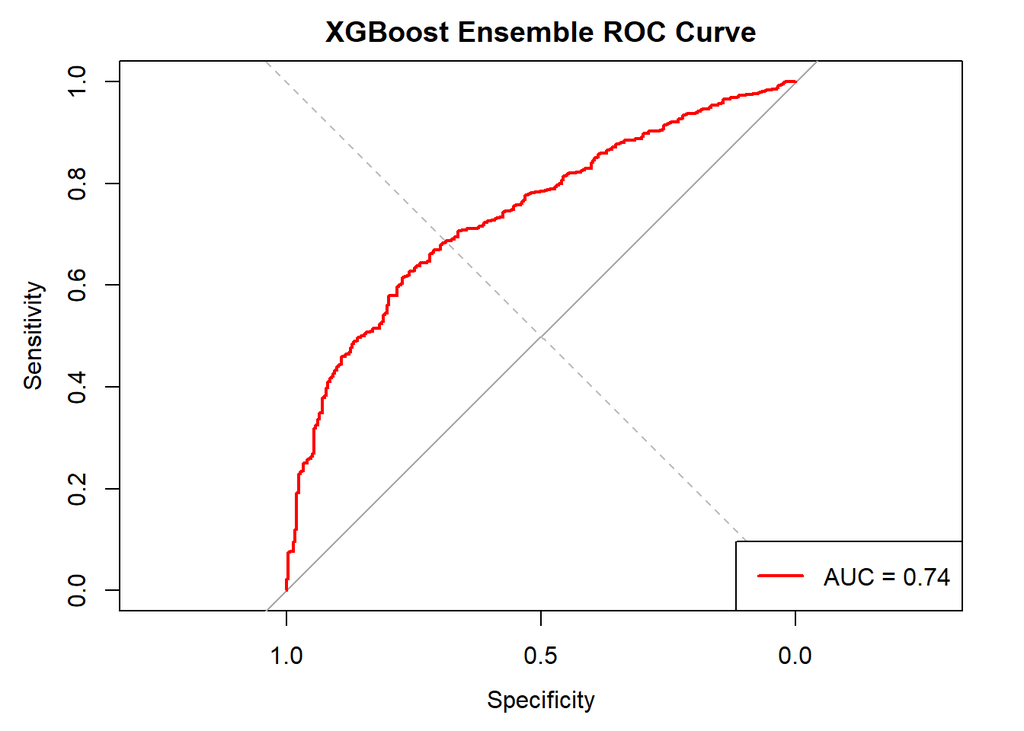

```
##
## Confusion Matrix:
```

```
## Confusion Matrix and Statistics
##
##           Reference
## Prediction Failure Success
##    Failure      42      27
##    Success     252     694
##
##                Accuracy : 0.7251
##                  95% CI : (0.6965, 0.7524)
##     No Information Rate : 0.7103
##     P-Value [Acc > NIR] : 0.1578
##
##                   Kappa : 0.1363
##
##  Mcnemar's Test P-Value : <2e-16
##
##             Sensitivity : 0.14286
##             Specificity : 0.96255
##          Pos Pred Value : 0.60870
##          Neg Pred Value : 0.73362
##              Prevalence : 0.28966
##          Detection Rate : 0.04138
##    Detection Prevalence : 0.06798
##       Balanced Accuracy : 0.55270
##
##        'Positive' Class : Failure
##
```

In the 3 models xgboost ensemble has the highest accuracy of 72.51%, while Random forest is just slightly behind at 72.12%. However, the sensitivity and f1 score of random forest is significantly better. It means that it will detect positive cases more reliably and the prediction for positives are more consistent. And random forest is rather robust and is less likely to be overfitted, which is important in this case.

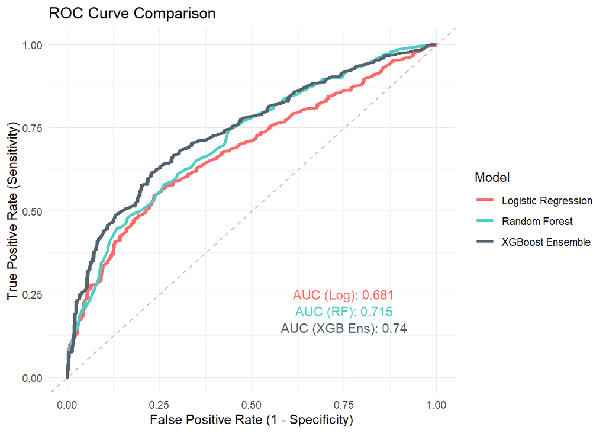

Model Performance Comparison: this is to compare the 3 models’ true Positive Rate (sensitivity) against the False Positive Rate. The AUC summarize the general performance

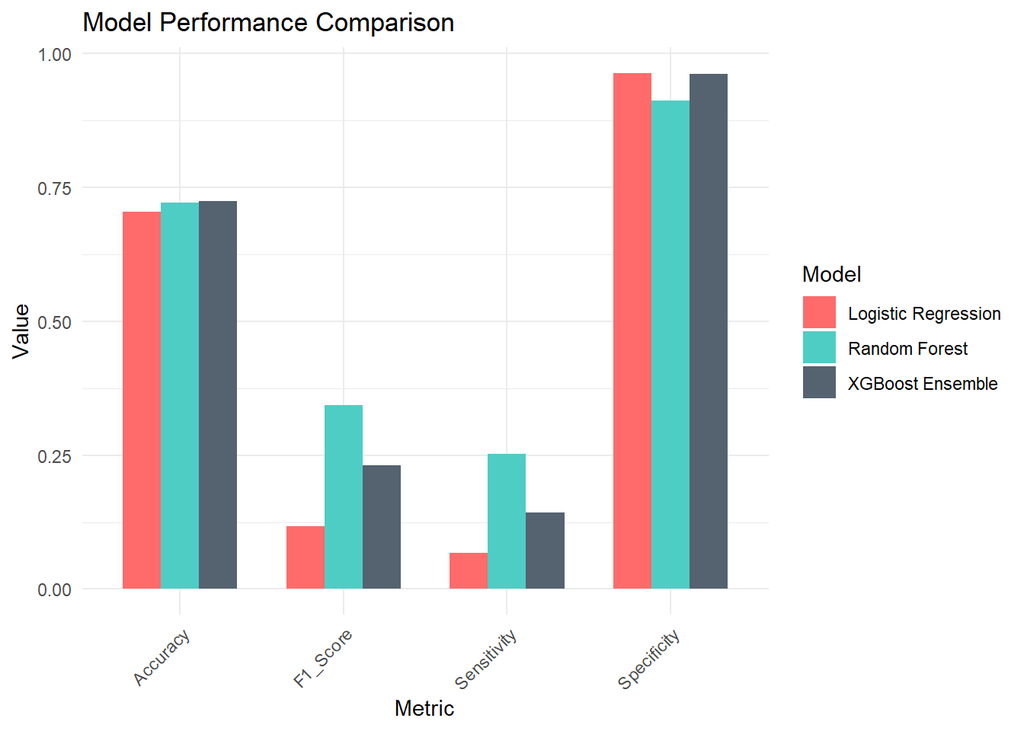

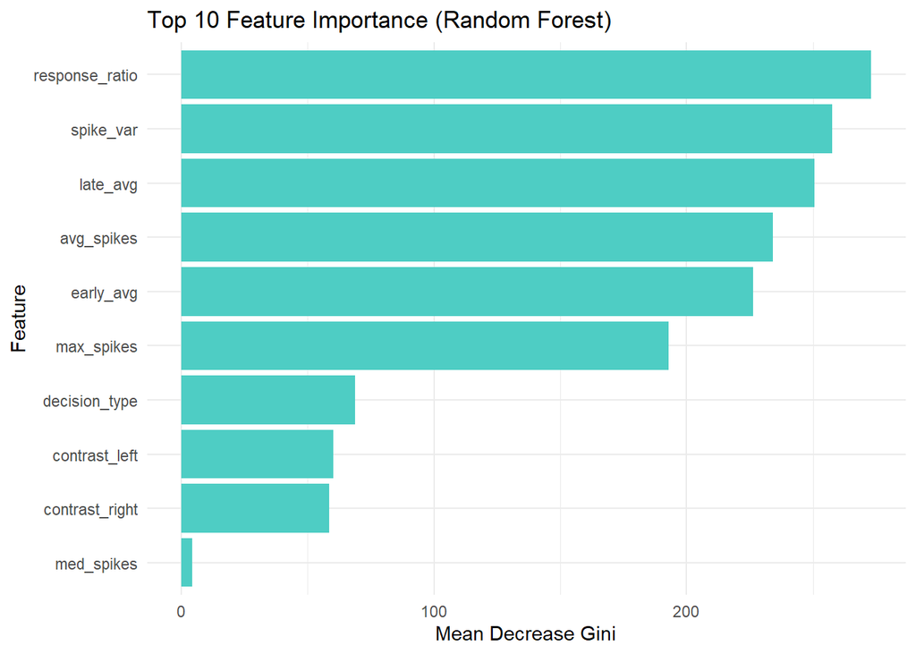

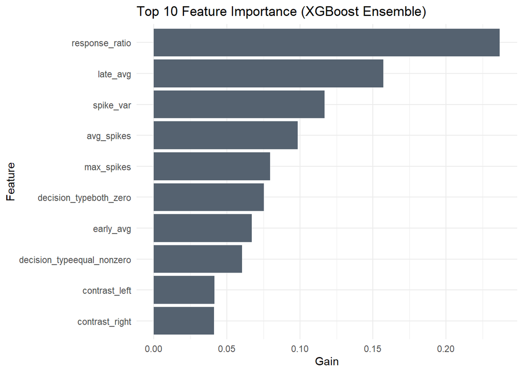

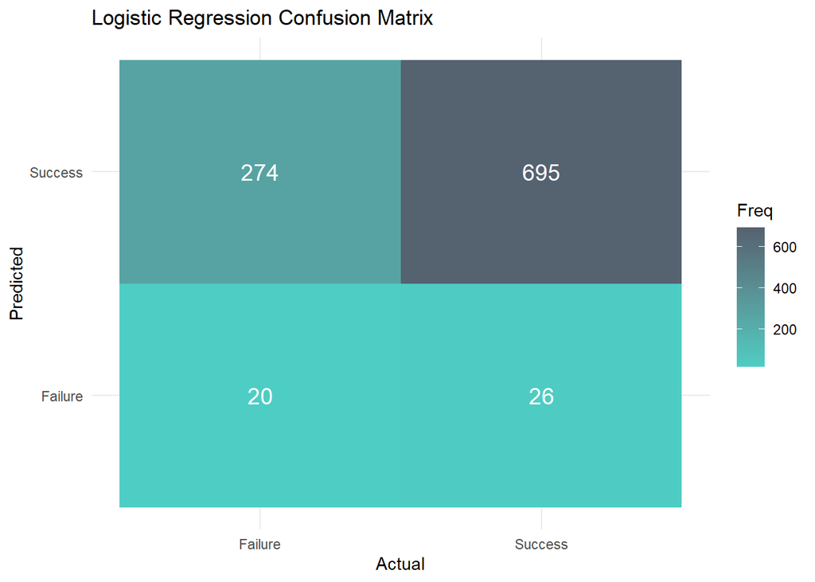

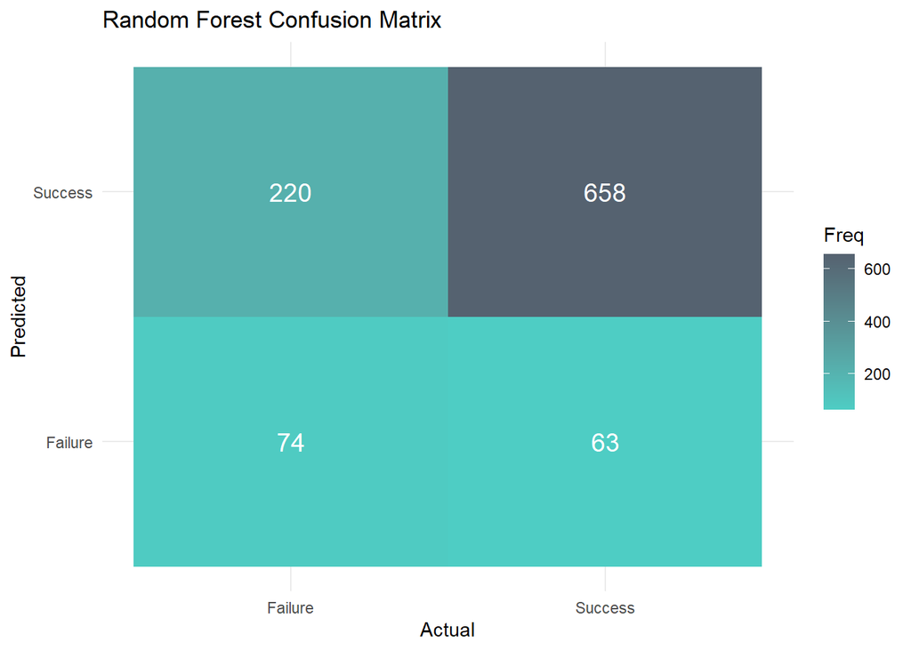

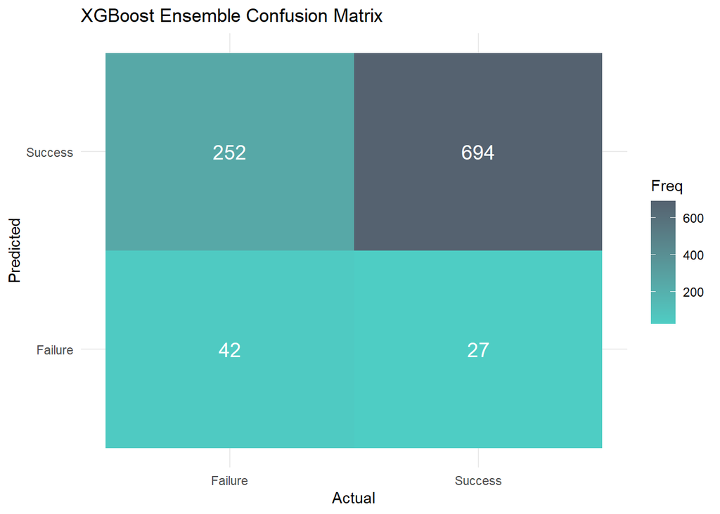

These are the confusion matrices for the 3 models. It is the actual vs predicted. It is there to check the True positive and negative, and False positive and negative.

```
## ===== Random Forest Model Evaluation on Test Datasets =====
```

```
## Using existing Random Forest model in the environment
```

```
##
## Processing test file: test1.rds
## Rows after NA removal: 100
## Class distribution:
##
## Failure Success
##      28      72
```

```
##
## ===== Random Forest Model Performance on Test 1 =====
## Accuracy: 75 %
## Sensitivity (True Positive Rate): 28.57 %
## Specificity (True Negative Rate): 93.06 %
## F1 Score: 39.02 %
## AUC: 0.751
##
## Confusion Matrix:
##           Reference
## Prediction Failure Success
##    Failure       8       5
##    Success      20      67
```

```
##
## Processing test file: test2.rds
## Rows after NA removal: 100
## Class distribution:
##
## Failure Success
##      27      73
```

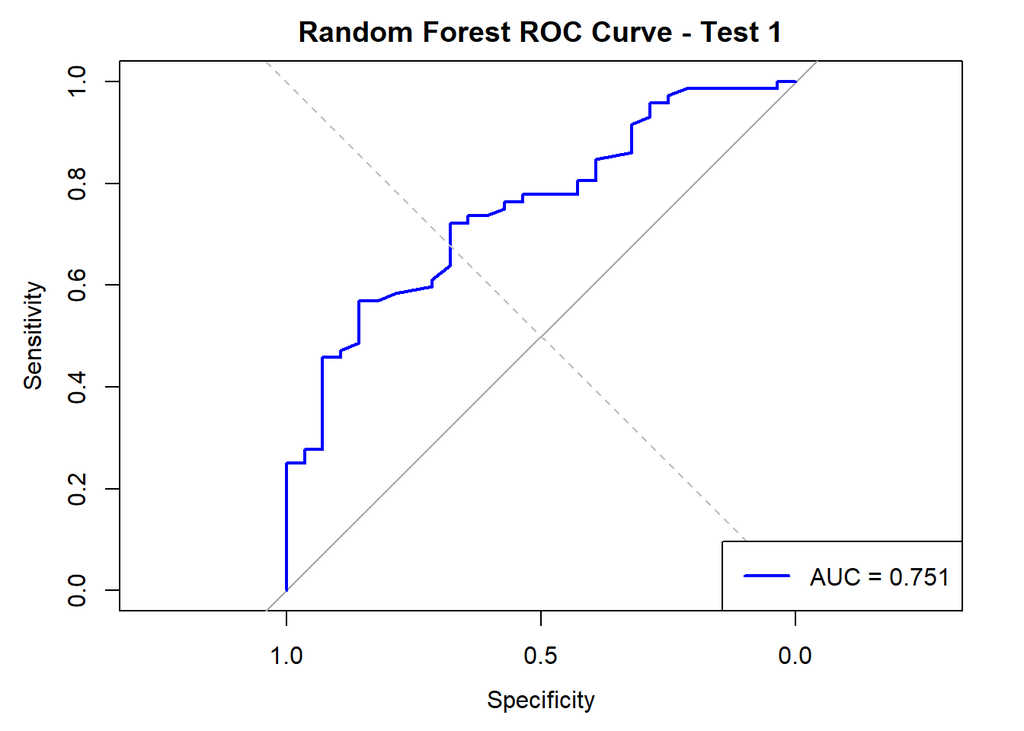

```
##
## ===== Random Forest Model Performance on Test 2 =====
## Accuracy: 74 %
## Sensitivity (True Positive Rate): 37.04 %
## Specificity (True Negative Rate): 87.67 %
## F1 Score: 43.48 %
## AUC: 0.73
##
## Confusion Matrix:
##           Reference
## Prediction Failure Success
##    Failure      10       9
##    Success      17      64
```

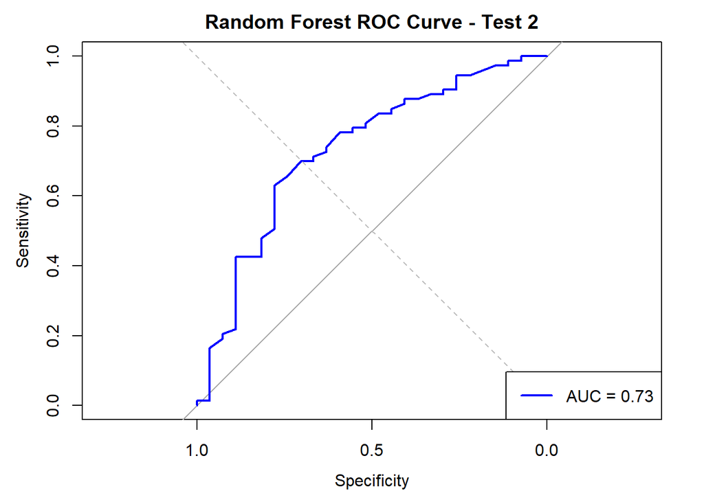

```
##
## ===== Random Forest Performance Comparison =====
##           Dataset Accuracy Sensitivity Specificity  F1_Score       AUC
## Accuracy   Test 1     0.75   0.2857143   0.9305556 0.3902439 0.7507440
## Accuracy1  Test 2     0.74   0.3703704   0.8767123 0.4347826 0.7300863
```

```
##
## ===== Random Forest Evaluation Complete =====
```

Discussion In the process of data integration, I kept the NA values after normalizing while setting up the training data. After that I use it on the test data set I saw a huge indent on the ROC curve the a large part of the curve even go under the line. I realized what i did wrong. Later on I omit the NA values it become much better.